# Scipy Tutorial

### Introduction to SciPy *(Scintific Python Library)*

Numpy provides a high-performance multidimensional array and basic tools to compute with and manipulate these arrays. SciPy builds on this, and provides a large number of functions that operate on numpy arrays and are useful for different types of scientific and engineering applications. Scipy, which is basic python library, designed on the top of Numpy library that gives more extension of finding scientific mathematical formulae like Matrix Rank, Inverse, polynomial equations, LU Decomposition, etc.

SciPy is organized into subpackages covering different scientific computing domains.

In this tutorial, we have few important sub packages and their basic operations and important functions.Below is the list of all the sub packages in Scipy:

| Subpackage | Description |
| --- | --- |
| *Cluster* | Clustering algorithms |
| *Constants* | Physical and mathematical constants |
| *Fftpack* | Fast Fourier Transform routines |
| *Integrate* | Integration and ordinary differential equation solvers |
| *Interpolate* | Interpolation and smoothing splines |
| *io* | Input and Output |
| *linalg* | Linear algebra |
| *ndimage* | N-dimensional image processing |
| *odr* | Orthogonal distance regression |
| *optimize* | Optimization and root-finding routines |
| *signal* | Signal processing |
| *sparse* | Sparse matrices and associated routines |
| *spatial* | Spatial data structures and algorithms |
| *special* | Special functions |
| *stats* | Statistical distributions and functions |

Here we will be discussing a few of the important sub-packages

##### **1. File Input-Ouput**

This package is useful in importing exporting file data.

```python
import numpy as np
from scipy import io as spio
a = np.ones((3, 3))
spio.savemat('file.mat', {'a': a}) # savemat expects a dictionary
data = spio.loadmat('file.mat')
data['a']
```

```
array([[1., 1., 1.],
       [1., 1., 1.],
       [1., 1., 1.]])
```

##### **2. Special Functions**

SciPy provides many special purpose functions for operations on data. Some of these functions are ->

Cube root function useful in calculating the cube root of each point in the dataset. (special.cbrt)

```python
from scipy import linalg
from scipy.special import cbrt
#Find cubic root of 8 & 125 using cbrt() function
cb = cbrt([8, 125])
#print value of cb
print(cb)
```

```
[2. 5.]
```

Permutaion function (scipy.special.perm) for finding permutations possible

```python
from scipy.special import perm
#find permutation of 5, 2 using perm (N, k) function
per = perm(5, 2, exact = True)
print(per)
```

```
20
```

Elliptic function (scipy.special.ellipj() for the Jacobian elliptic function

Erf function for the area under a Gaussian curve: scipy.special.erf()

##### **3. Linear Algebra Functions**

The scipy.linalg module provides standard linear algebra operations which are helpful for:

Eigenvalue problems – computing eigen value problems for Hermitian metrix, tridiagonal matrix, etc.

Decompositions – compute singular value of matrix, hessenberg form of matrix, converting complex eigen values to real eigen values, etc.

Matrix functions like inverse, determinant of matrix , finding eigen values of matrix, subspace angles of matrix etc.

Below are example of linear algebra functions:

•The **scipy.linalg.det()** function computes the determinant of a square matrix. from scipy import linalg

```python
from scipy import linalg
arr = np.array([[1, 2],
                [3, 4]])
linalg.det(arr)
```

```
-2.0
```

•The **scipy.linalg.inv()** function computes the inverse of a square matrix

```python
arr = np.array([[1, 2],
                [3, 4]])
iarr = linalg.inv(arr)
iarr
```

```
array([[-2. ,  1. ],
       [ 1.5, -0.5]])
```

##### **4. Statistics and Random Numbers**

The module **scipy.stats** contains statistical tools and probabilistic descriptions of random processes. Random number generators for various random process can be found in numpy.random. statistics functions are used for :

Statistical tests –like test whether a dataset has normal kurtosis, test whether sample differs from normal distribution etc.

Histogram and probability density function

Mean, median and percentiles  
Below is example for calculating mean

```python
import numpy as np
from scipy import stats
samples = np.random.normal(size=1000)
print(np.mean(samples))
```

```
-0.02764132782115672
```

##### **5. Integration Techniques**

The **scipy.integrate** sub-package provides several integration techniques including an ordinary differential equation integrator. Below are some useful integration functions:

Quad – General purpose integration

Dblquad – General purpose double integratio

Tplquad – General purpose triple integration

Romberg – Integrate function using Romberg function

Below is the example to integrate a simple sine function from 0 to pi/2 using quad.

```python
from scipy.integrate import quad
res = quad(np.sin, 0, np.pi/2)
print(res)
```

```
(0.9999999999999999, 1.1102230246251564e-14)
```

##### **6. Image Manipulation Techniques**

Python scipy has ndimage library which can be used to manipulate images.  
Below is example to read an image from misc library

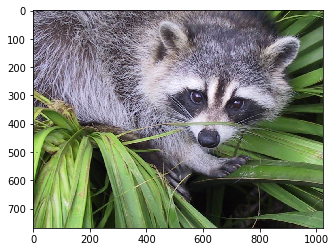

```python
from scipy import misc
f = misc.face()
import matplotlib.pyplot as plt
plt.imshow(f)
plt.show()
```

Below is example to crop an image

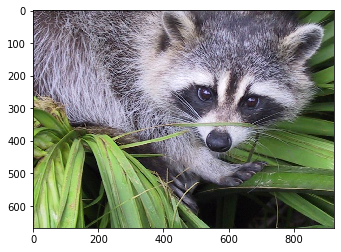

```python
from scipy import ndimage
cropped_f = f[50:-50, 50:-50]
import matplotlib.pyplot as plt
plt.imshow(cropped_f)
plt.show()
```

Below is example to rotate an image from misc library

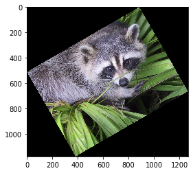

```python
from scipy import ndimage
rotated_f = ndimage.rotate(f, 30)
import matplotlib.pyplot as plt
plt.imshow(rotated_f)
plt.show()
```

##### **References:**

http://scipy-lectures.org/advanced/image_processing/

https://scipy-lectures.org/intro/scipy.html#statistics-and-random-numbers-scipy-stats

https://www.guru99.com/scipy-tutorial.html

https://scipy-lectures.org/